# The tidyverse

Data analysis and visualization using R 2

Michiel Noback

April 2020

# Course contents

# Focus of the course

This course has two main focus points:

- data mangling and explorations
- data visualizations

# The Tidyverse

# Background

> The tidyverse is an opinionated collection of R packages designed for data science. All packages share an underlying design philosophy, grammar, and data structures.

Hadley Wickham is the driving force behind the tidyverse.

# The book

- There is a book dedicated to the tidyverse: R for Data Science.
- It is available for free online: https://r4ds.had.co.nz/

[figure not shown]

# Packages

# Package listing

Except for `readr` you will see all of the core packages of the tidyverse:

- `ggplot2`: visualization
- `tidyr`: tidying
- `dplyr`: mangling
- `lubridate`: date and time
- `stringr`: character data and regex

# Old school Data Science

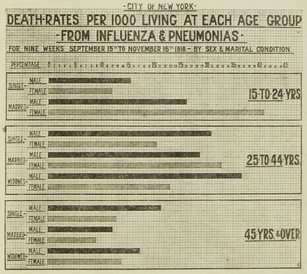

# ggplot2

You will learn about the grammar of graphics and how you use a layered architecture to build your plot from data to axis labels and plot theme.

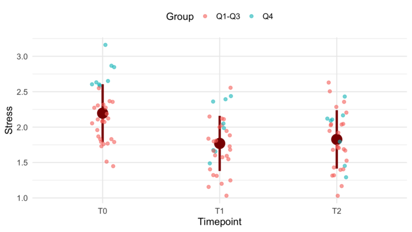

# tidyr

Using the functions from the `tidyr` package you will learn how to clean you data and convert it into *tidy* format and into other formats.

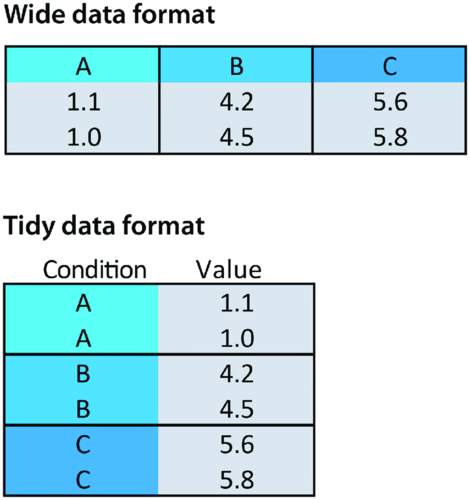

# dplyr

The `dplyr` package is the Swiss army knife of data mangling. You use it to select, filter, mutate, arrange, summarize and a whole bunch of other operations.

[figure not shown]

# lubridate

Package `lubridate` makes working with dates and time less gruesome. How do you calculate the passed hours between April 4th 2019, 17:00 PM and May 16 2020, 12:30 AM? (Actually, I would have to look that up as well)

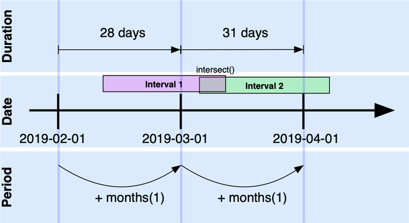

# stringr

The stringr package focuses on manipulating and scanning character data.

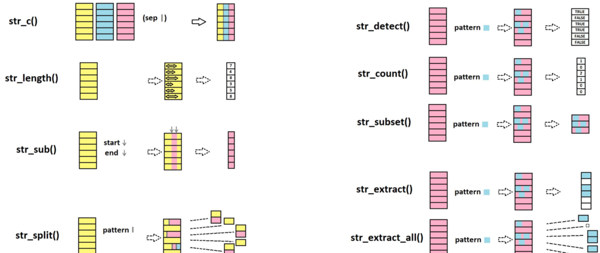

Disclaimer: knowledge of regex is pretty much essential.

# Resources

The course has several resources and they can als be accessed via te course website.

- The [DAVuR2 Course Website](https://michielnoback.github.io/bincourses/davur2.html)
- The [eBook](https://michielnoback.github.io/bincourses/course_contents/davur2/book/)
- The (course datasets repo)[https://github.com/MichielNoback/datasets]

# Assessment

In this year of social distancing, the course will be assessed by means of an open book, take home exam. It has a duration of exactly one working day.